# Ford GoBike System Data

#### Introduction

##### Dataset Introduction:

The Ford GoBike System dataset includes information about individual rides made in a bike-sharing system covering the greater San Francisco Bay area. It captures details such as trip duration, start and end locations, user type, member information, and more.

## Preliminary Wrangling

```python
# import all packages and set plots to be embedded inline
import numpy as np
import pandas as pd
import matplotlib.pyplot as plt
import seaborn as sns

sns.set_style('darkgrid')

%matplotlib inline

import warnings
warnings.filterwarnings('ignore')
```

```python
bike =pd.read_csv('201902-fordgobike-tripdata.csv')
#Display #rows, #columns
print('_____________________________________________________________________')
print(bike.shape)
print('_____________________________________________________________________')
#Display basic information about the dataset
print(bike.info())
print('_____________________________________________________________________')
#Display information about the data types of each column in the DataFrame.
print(bike.dtypes)
print('_____________________________________________________________________')
# Display first few rows of the dataset
bike.head(5)
```

```
_____________________________________________________________________
(183412, 16)
_____________________________________________________________________
<class 'pandas.core.frame.DataFrame'>
RangeIndex: 183412 entries, 0 to 183411
Data columns (total 16 columns):
 #   Column                   Non-Null Count   Dtype
---  ------                   --------------   -----
 0   duration_sec             183412 non-null  int64
 1   start_time               183412 non-null  object
 2   end_time                 183412 non-null  object
 3   start_station_id         183215 non-null  float64
 4   start_station_name       183215 non-null  object
 5   start_station_latitude   183412 non-null  float64
 6   start_station_longitude  183412 non-null  float64
 7   end_station_id           183215 non-null  float64
 8   end_station_name         183215 non-null  object
 9   end_station_latitude     183412 non-null  float64
 10  end_station_longitude    183412 non-null  float64
 11  bike_id                  183412 non-null  int64
 12  user_type                183412 non-null  object
 13  member_birth_year        175147 non-null  float64
 14  member_gender            175147 non-null  object
 15  bike_share_for_all_trip  183412 non-null  object
dtypes: float64(7), int64(2), object(7)
memory usage: 22.4+ MB
None
_____________________________________________________________________
duration_sec                 int64
start_time                  object
end_time                    object
start_station_id           float64
start_station_name          object
start_station_latitude     float64
start_station_longitude    float64
end_station_id             float64
end_station_name            object
end_station_latitude       float64
end_station_longitude      float64
bike_id                      int64
user_type                   object
member_birth_year          float64
member_gender               object
bike_share_for_all_trip     object
dtype: object
_____________________________________________________________________
```

|  | duration_sec | start_time | end_time | start_station_id | start_station_name | start_station_latitude | start_station_longitude | end_station_id | end_station_name | end_station_latitude | end_station_longitude | bike_id | user_type | member_birth_year | member_gender | bike_share_for_all_trip |
| --- | --- | --- | --- | --- | --- | --- | --- | --- | --- | --- | --- | --- | --- | --- | --- | --- |
| 0 | 52185 | 2019-02-28 17:32:10.1450 | 2019-03-01 08:01:55.9750 | 21.0 | Montgomery St BART Station (Market St at 2nd St) | 37.789625 | -122.400811 | 13.0 | Commercial St at Montgomery St | 37.794231 | -122.402923 | 4902 | Customer | 1984.0 | Male | No |
| 1 | 42521 | 2019-02-28 18:53:21.7890 | 2019-03-01 06:42:03.0560 | 23.0 | The Embarcadero at Steuart St | 37.791464 | -122.391034 | 81.0 | Berry St at 4th St | 37.775880 | -122.393170 | 2535 | Customer | NaN | NaN | No |
| 2 | 61854 | 2019-02-28 12:13:13.2180 | 2019-03-01 05:24:08.1460 | 86.0 | Market St at Dolores St | 37.769305 | -122.426826 | 3.0 | Powell St BART Station (Market St at 4th St) | 37.786375 | -122.404904 | 5905 | Customer | 1972.0 | Male | No |
| 3 | 36490 | 2019-02-28 17:54:26.0100 | 2019-03-01 04:02:36.8420 | 375.0 | Grove St at Masonic Ave | 37.774836 | -122.446546 | 70.0 | Central Ave at Fell St | 37.773311 | -122.444293 | 6638 | Subscriber | 1989.0 | Other | No |
| 4 | 1585 | 2019-02-28 23:54:18.5490 | 2019-03-01 00:20:44.0740 | 7.0 | Frank H Ogawa Plaza | 37.804562 | -122.271738 | 222.0 | 10th Ave at E 15th St | 37.792714 | -122.248780 | 4898 | Subscriber | 1974.0 | Male | Yes |

```python
# descriptive statistics for the numeric variable
bike.duration_sec.describe()
```

```
count    183412.000000
mean        726.078435
std        1794.389780
min          61.000000
25%         325.000000
50%         514.000000
75%         796.000000
max       85444.000000
Name: duration_sec, dtype: float64
```

```python
# check for null values
bike.isnull().sum()
```

```
duration_sec                  0
start_time                    0
end_time                      0
start_station_id            197
start_station_name          197
start_station_latitude        0
start_station_longitude       0
end_station_id              197
end_station_name            197
end_station_latitude          0
end_station_longitude         0
bike_id                       0
user_type                     0
member_birth_year          8265
member_gender              8265
bike_share_for_all_trip       0
dtype: int64
```

### Data Cleaning

###### Issue #1:

- Define: Drop the rows with missing values

```python
# code:
bike.dropna(inplace=True)
# check:
bike.isnull().any().sum()
```

```
0
```

###### Issue #2:

The `start_time` and `end_time` are object type, but they should be datetime values. _____________________________________________________________________

- Define: Convert them to datetime

```python
# code:
bike['start_time'] = pd.to_datetime(bike['start_time'])
bike['end_time'] = pd.to_datetime(bike['end_time'])

#check:
print(bike['start_time'][0])
print(bike['end_time'][0])
```

```
2019-02-28 17:32:10.145000
2019-03-01 08:01:55.975000
```

###### Issue #3:

- Define: converting them to integer types might be more appropriate.

```python
# code:
bike['member_birth_year'] = bike['member_birth_year'].astype('Int64')  # Use 'Int64' to handle NaNs
bike['bike_id'] =bike['bike_id'].astype('int')

# check:
print(bike.dtypes)
```

```
duration_sec                        int64
start_time                 datetime64[ns]
end_time                   datetime64[ns]
start_station_id                  float64
start_station_name                 object
start_station_latitude            float64
start_station_longitude           float64
end_station_id                    float64
end_station_name                   object
end_station_latitude              float64
end_station_longitude             float64
bike_id                             int32
user_type                          object
member_birth_year                   Int64
member_gender                      object
bike_share_for_all_trip            object
dtype: object
```

```python
# Descriptive statistics for the numeric variable.
bike.duration_sec.describe()
```

```
count    174952.000000
mean        704.002744
std        1642.204905
min          61.000000
25%         323.000000
50%         510.000000
75%         789.000000
max       84548.000000
Name: duration_sec, dtype: float64
```

```python
# Import the datetime module from Python's standard library
import datetime as dt

# Extract the day from the start day
bike['start_day'] = bike['start_time'].dt.day_name()
# Extract the month from the start day
bike['start_month'] = bike['start_time'].dt.month_name()
# Extract the hour from the start day
bike['start_hr'] = bike['start_time'].dt.hour
# Convert the 'start_hr' column values to strings.
bike['start_hr'] = bike.start_hr.astype(str)


# Extract the day from the end day
bike['end_day'] = bike['end_time'].dt.day_name()
# Extract the month from the end day
bike['end_month'] = bike['end_time'].dt.month_name()
# Extract the hour from the end day
bike['end_hr'] = bike['end_time'].dt.hour
# Convert the 'end_hr' column values to strings.
bike['end_hr'] = bike.end_hr.astype(str)

bike.head()
```

|  | duration_sec | start_time | end_time | start_station_id | start_station_name | start_station_latitude | start_station_longitude | end_station_id | end_station_name | end_station_latitude | ... | user_type | member_birth_year | member_gender | bike_share_for_all_trip | start_day | start_month | start_hr | end_day | end_month | end_hr |
| --- | --- | --- | --- | --- | --- | --- | --- | --- | --- | --- | --- | --- | --- | --- | --- | --- | --- | --- | --- | --- | --- |
| 0 | 52185 | 2019-02-28 17:32:10.145 | 2019-03-01 08:01:55.975 | 21.0 | Montgomery St BART Station (Market St at 2nd St) | 37.789625 | -122.400811 | 13.0 | Commercial St at Montgomery St | 37.794231 | ... | Customer | 1984 | Male | No | Thursday | February | 17 | Friday | March | 8 |
| 2 | 61854 | 2019-02-28 12:13:13.218 | 2019-03-01 05:24:08.146 | 86.0 | Market St at Dolores St | 37.769305 | -122.426826 | 3.0 | Powell St BART Station (Market St at 4th St) | 37.786375 | ... | Customer | 1972 | Male | No | Thursday | February | 12 | Friday | March | 5 |
| 3 | 36490 | 2019-02-28 17:54:26.010 | 2019-03-01 04:02:36.842 | 375.0 | Grove St at Masonic Ave | 37.774836 | -122.446546 | 70.0 | Central Ave at Fell St | 37.773311 | ... | Subscriber | 1989 | Other | No | Thursday | February | 17 | Friday | March | 4 |
| 4 | 1585 | 2019-02-28 23:54:18.549 | 2019-03-01 00:20:44.074 | 7.0 | Frank H Ogawa Plaza | 37.804562 | -122.271738 | 222.0 | 10th Ave at E 15th St | 37.792714 | ... | Subscriber | 1974 | Male | Yes | Thursday | February | 23 | Friday | March | 0 |
| 5 | 1793 | 2019-02-28 23:49:58.632 | 2019-03-01 00:19:51.760 | 93.0 | 4th St at Mission Bay Blvd S | 37.770407 | -122.391198 | 323.0 | Broadway at Kearny | 37.798014 | ... | Subscriber | 1959 | Male | No | Thursday | February | 23 | Friday | March | 0 |

5 rows × 22 columns

```python
print(bike.shape)
```

```
(174952, 22)
```

### What is/are the main feature(s) of interest in your dataset?

> Trip duration, start time, end time,member data, and user type

### What features in the dataset do you think will help support your investigation into your feature(s) of interest?

> Start and end stations, user age, Bike Share for All Trip, and gender.

## Univariate Exploration

#### Number of bicycle service users

```python
# There is ony two type of user
bike.user_type.unique()
```

```
array(['Customer', 'Subscriber'], dtype=object)
```

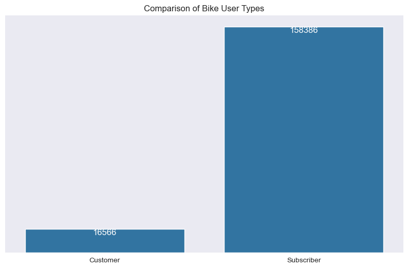

```python
# Display the number of users using a count plot

plt.figure(figsize=(10,6))
base_color = sns.color_palette()[0]
ax = sns.countplot(data=bike, x ='user_type', color=base_color)

# Add annotations to the plot
total_points  = bike.shape[0]
category_counts  = bike['user_type'].value_counts()
positions, labels = plt.xticks() # get the current tick locations and labels

# loop through each pair of locations and labels
for position, label in zip(positions, labels):

    # get the text property for the label to get the correct count
    count = category_counts [label.get_text()]
    pct_string = '{}'.format(count)

    # print the annotation just below the top of the bar
    plt.text(position, count-8, pct_string, va='top', ha='center', color = 'w', fontsize=12)

plt.title('Comparison of Bike User Types')

# Remove unnecessary features
ax.spines['top'].set_visible(False)
ax.spines['right'].set_visible(False)
ax.spines['left'].set_visible(False)
plt.yticks([])
plt.ylabel('')
plt.xlabel('')

# Show the plot
plt.show();
```

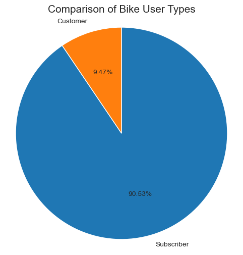

```python
plt.figure(figsize=(10,6))
sorted_counts = bike['user_type'].value_counts()
color_palette = sns.color_palette("pastel")

plt.pie(
    sorted_counts,
    labels = sorted_counts.index,
    startangle = 90,
    counterclock = False,
    autopct='%1.2f%%',
    );

plt.axis('square')
plt.title('Comparison of Bike User Types', fontsize=15);
```

#### The Average Trip Duration?

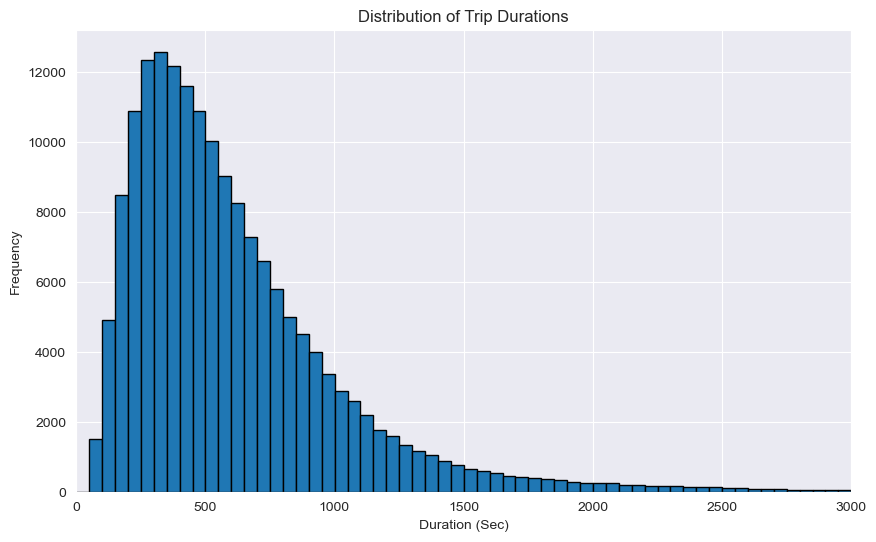

```python
# Define the bin size and calculate bin edges
binsize = 50
max_duration = bike['duration_sec'].max()
bins = np.arange(1, max_duration + binsize, binsize)

# Create the histogram plot
plt.figure(figsize=[10, 6])
plt.hist(bike['duration_sec'], bins=bins, edgecolor='black')
plt.xlabel('Duration (Sec)')
plt.ylabel('Frequency')
plt.xlim(0, 3000)
plt.title('Distribution of Trip Durations')
plt.grid(True)
plt.show()
```

```python
# Calcluate the avarage.
average_duration = np.mean(bike['duration_sec'])
print("Avarage duration: ", average_duration)
```

```
Avarage duration:  704.0027436096758
```

##### The average trip duration is approximately 703 (11 minutes and 43 seconds).

#### The Relationship Between Trip Duration and User Type?

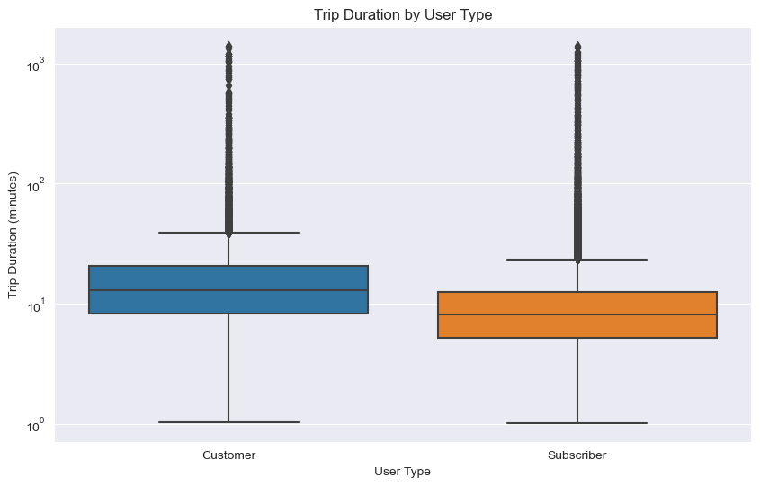

```python
# Convert 'duration_sec' to minutes for better readability
bike['duration_min'] = bike['duration_sec'] / 60

# Create a box plot to visualize trip duration by user type
plt.figure(figsize=(10, 6))
sns.boxplot(data=bike, x='user_type', y='duration_min')
plt.title('Trip Duration by User Type')
plt.xlabel('User Type')
plt.ylabel('Trip Duration (minutes)')
plt.yscale('log')
plt.show()
```

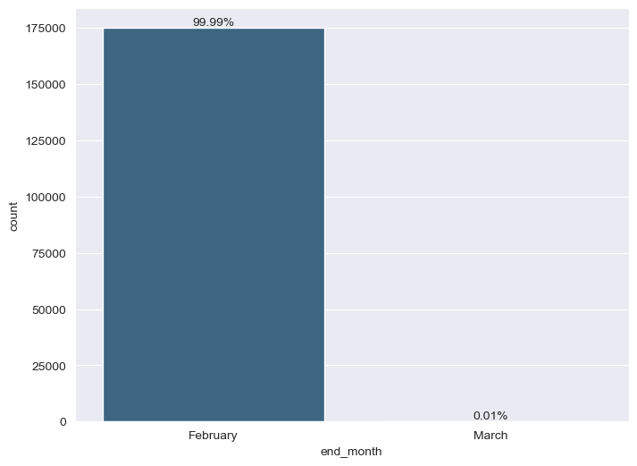

```python
fig, ax = plt.subplots(figsize=(8, 6))

sns.countplot(data=bike,
              x='end_month',
              ax=ax, palette='viridis',
              order=bike['end_month'].value_counts().index)

total_records = bike.shape[0]

for container in ax.containers:
    ax.bar_label(container, labels=[f'{100 * h.get_height() / total_records:.2f}%' for h in container], label_type='edge', fontsize=10)

plt.show()
```

```python
bike['month'] = bike['start_time'].dt.month_name()
bike.month.value_counts()
```

```
month
February    174952
Name: count, dtype: int64
```

```python
bike['month'] = bike['end_time'].dt.month_name()

bike.month.value_counts()
```

```
month
February    174938
March           14
Name: count, dtype: int64
```

##### All the trips started and ended in February except for a very few (14) which ended in March

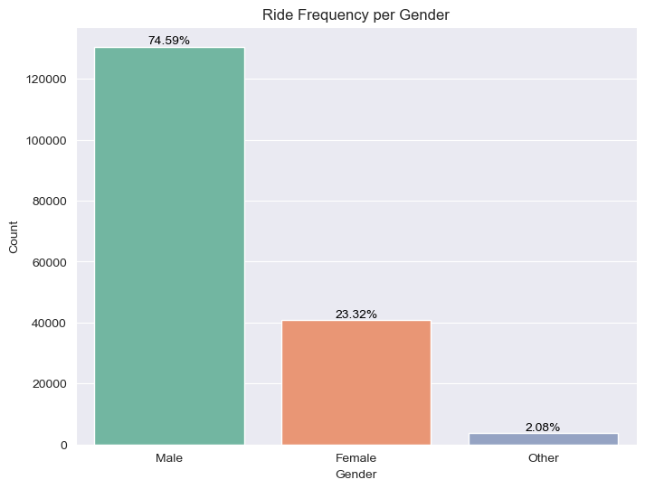

```python
# Set the figure size
plt.figure(figsize=(8, 6))

sns.countplot(data=bike,
              x='member_gender',
              hue=None,
              palette='Set2',
              order=bike['member_gender'].value_counts().index)

total_count = bike.shape[0]

for container in plt.gca().containers:
    labels = [f'{100 * v / total_count:.2f}%' for v in container.datavalues]
    plt.gca().bar_label(container, labels=labels, label_type='edge', fontsize=10, color='black')

plt.xlabel('Gender')
plt.ylabel('Count')
plt.title('Ride Frequency per Gender')

# Show the plot
plt.show()
```

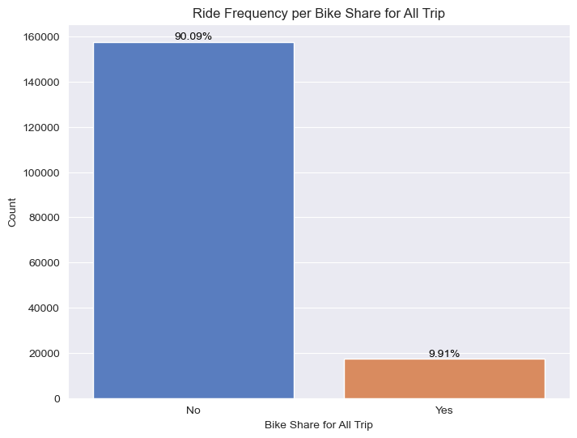

```python
# Create the figure and axes for the plot
fig, ax = plt.subplots(figsize=(8, 6))

sns.countplot(data=bike,
              x='bike_share_for_all_trip',
              palette='muted',
              order=bike['bike_share_for_all_trip'].value_counts().index,
              ax=ax)

total_records = bike.shape[0]

for p in ax.containers[0]:
    height = p.get_height()
    percentage = f'{height / total_records:.2%}'
    ax.annotate(percentage, (p.get_x() + p.get_width() / 2, height),
                ha='center', va='bottom', fontsize=10, color='black')

ax.set_xlabel('Bike Share for All Trip')
ax.set_ylabel('Count')
ax.set_title('Ride Frequency per Bike Share for All Trip')

# Show the plot
plt.show()
```

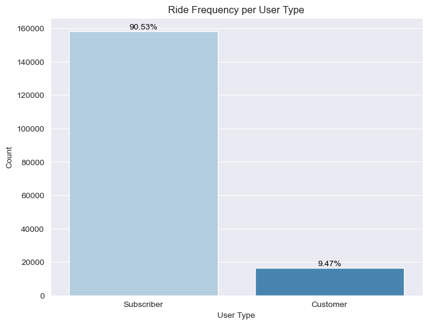

```python
fig, ax = plt.subplots(figsize=(8, 6))

sns.countplot(data=bike,
              x='user_type',
              palette='Blues',
              order=bike['user_type'].value_counts().index,
              ax=ax)

total_records = len(bike)

for p in ax.containers[0]:
    height = p.get_height()
    percentage = f'{height / total_records:.2%}'
    ax.annotate(percentage, (p.get_x() + p.get_width() / 2, height),
                ha='center', va='bottom', fontsize=10, color='black')

ax.set_xlabel('User Type')
ax.set_ylabel('Count')
ax.set_title('Ride Frequency per User Type')

plt.show()
```

#### Trip Duration vs. Age

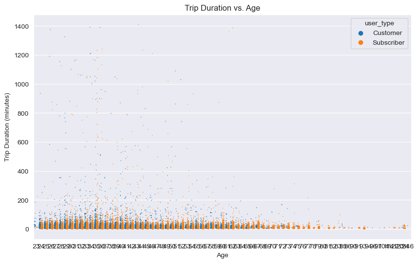

```python
from datetime import datetime

# Calculate the current year
current_year = datetime.now().year

# Create an 'age' column
bike['age'] = current_year - bike['member_birth_year']

# Plot the scatter plot: Age vs. Trip Duration
plt.figure(figsize=(10, 6))
sns.stripplot(data=bike, x='age', y='duration_min', hue='user_type',
              size=1, jitter= 0.35, dodge=True)
plt.title('Trip Duration vs. Age')
plt.xlabel('Age')
plt.ylabel('Trip Duration (minutes)')
plt.show()
```

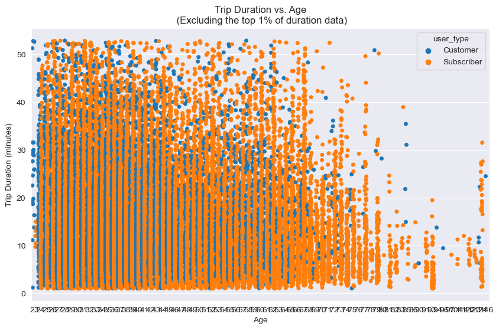

```python
current_year = datetime.now().year

# Create an 'age' column
bike['age'] = current_year - bike['member_birth_year']

# Exclude the top 1% of duration data
bike_filtered = bike.query('duration_min < duration_min.quantile(0.99)')

# Plot the scatter plot: Age vs. Trip Duration
plt.figure(figsize=(10, 6))
sns.stripplot(data=bike_filtered, x='age', y='duration_min', hue='user_type',
              jitter=0.35, dodge=True)  # Removed size=1 as it has no effect on stripplot
plt.title('Trip Duration vs. Age\n (Excluding the top 1% of duration data)')
plt.xlabel('Age')
plt.ylabel('Trip Duration (minutes)')
plt.show()
```

#### Trip Duration by Month and User Type

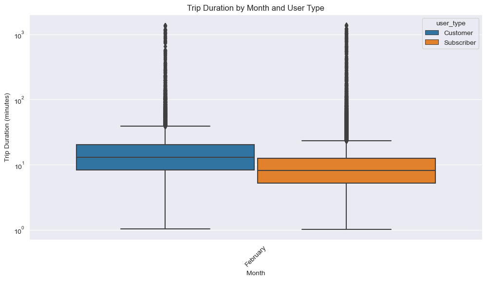

```python
# Assuming 'start_time' is a datetime column in the dataset
bike['month'] = bike['start_time'].dt.month_name()
plt.figure(figsize=(12, 6))
sns.boxplot(data=bike, x='month', y='duration_min', hue='user_type')
plt.title('Trip Duration by Month and User Type')
plt.xlabel('Month')
plt.ylabel('Trip Duration (minutes)')
plt.xticks(rotation=45)
plt.yscale('log')
plt.show()
```

#### In the same month, February, subscribers have shorter durations than customers.

#### Trip Start Time vs. Trip Duration

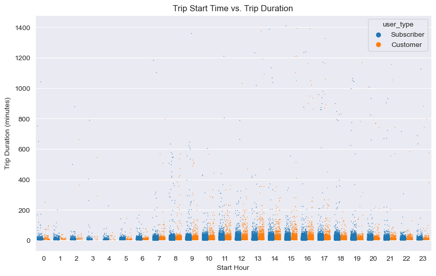

```python
# Convert start time to hour
bike['start_hour'] = bike['start_time'].dt.hour
plt.figure(figsize=(10, 6))
sns.stripplot(data=bike, x='start_hour', y='duration_min', hue='user_type',
                size=1, jitter= 0.35, dodge=True)
plt.title('Trip Start Time vs. Trip Duration')
plt.xlabel('Start Hour')
plt.ylabel('Trip Duration (minutes)')
plt.show()
```

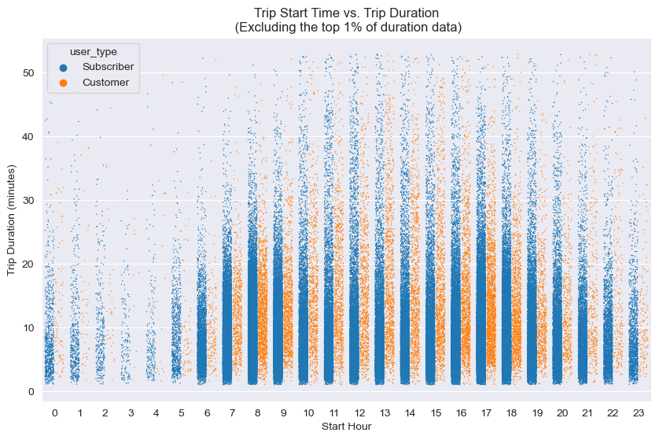

```python
# Convert start time to hour
bike ['start_hour'] = bike ['start_time'].dt.hour
plt.figure(figsize=(10, 6))

sns.stripplot(data=bike.query('duration_min<duration_min.quantile (0.99)'),
              x='start_hour',
              y='duration_min',
              hue='user_type',
              size=1, jitter=0.35, dodge=True)
plt.title('Trip Start Time vs. Trip Duration\n (Excluding the top 1% of duration data)')
plt.xlabel('Start Hour')
plt.ylabel('Trip Duration (minutes)')
plt.show()
```

#### Overall, when starting at times between 1 PM and 5 PM, the duration tends to be longer.

> Number of Bicycle Service Users -> Count Plot and Pie Chart: Both plots clearly show the distribution of users between 'Customer' and 'Subscriber'. The count plot with annotations provides a detailed view of the counts, while the pie chart offers a percentage-based comparison.

> Average Trip Duration -> Histogram: The histogram effectively shows the distribution of trip durations. The average duration calculation (approximately 703 seconds) aligns from the histogram. The histogram also helps identify the range where most trips fall.

> I converted 'duration_sec' to minutes for better readability in the box plot, which is a good choice for understanding trip duration in a more relatable unit, and I used it in third quation .

> There are more of subscribers (about 90%) than normal customers

> More non bike sharing for all trip (about 90%) that bike sharing for all trip.

> Most of the riders are male (>70%)

## Bivariate Exploration

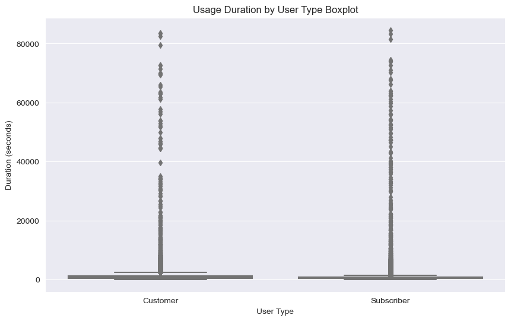

```python
# Make filter based on user type
fig, ax = plt.subplots(figsize=(10, 6))

ax.set_title('Usage Duration by User Type Boxplot')

sns.boxplot(data=bike, x='user_type', y='duration_sec', palette='pastel', ax=ax)

ax.set_xlabel('User Type')
ax.set_ylabel('Duration (seconds)')

plt.show()
```

```python
avg_customer_duration = bike[bike['user_type'] == 'Customer']['duration_sec'].mean()
avg_subscriber_duration = bike[bike['user_type'] == 'Subscriber']['duration_sec'].mean()
```

```python
# Average trip duration for Customer/Casual
avg_customer_duration
```

```
1310.656102861282
```

```python
# Average trip duration for Customer/Casual

avg_subscriber_duration
```

```
640.5513050395869
```

##### It seems that duration average for Customer is higher than Subscriber

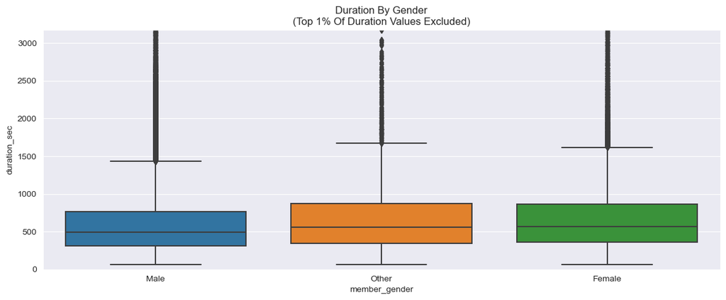

```python
plt.figure(figsize=(14,5))
grid = sns.boxplot(data=bike, y='duration_sec', x='member_gender')
plt.ylim([0,bike['duration_sec'].quantile(0.99)])
plt.title('Duration by gender\n(Top 1% of duration values excluded)'.title())
plt.show()
```

##### The female gender spend higher time on average than male.

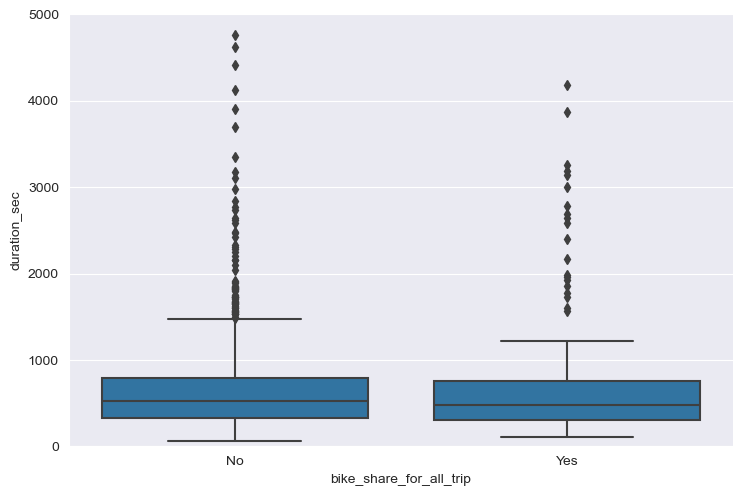

```python
sample_indices = np.random.choice(bike.index, 2000, replace=False)
bike_sample = bike.loc[sample_indices, :]

def create_boxplot(x, y, **kwargs):
    boxplot_color = sns.color_palette()[0]
    sns.boxplot(x=x, y=y, color=boxplot_color)

plt.figure(figsize=(5, 5))
grid = sns.PairGrid(data=bike_sample, y_vars=['duration_sec'],
                   x_vars=['bike_share_for_all_trip'],
                   height=5, aspect=1.5)
grid.map(create_boxplot)
plt.ylim([0, 5000])
plt.show()
```

##### The average bike share participation rate is fairly consistent across all categories.

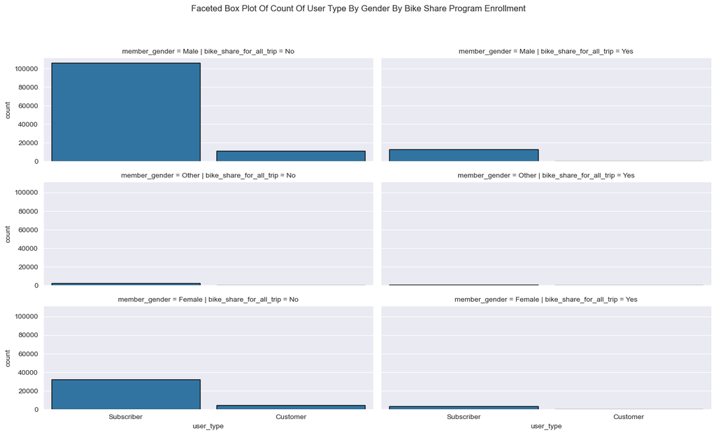

```python
g = sns.FacetGrid(data=bike, col='bike_share_for_all_trip', row='member_gender', height=4, aspect=1.5)

g.map(sns.countplot, "user_type", order=bike['user_type'].value_counts().index, edgecolor='black', width=0.9)

plt.subplots_adjust(top=0.9)
g.fig.suptitle("Faceted Box Plot of Count of User Type by Gender by Bike Share Program Enrollment".title(), y=1.05)

g.fig.set_size_inches(14, 8)

plt.tight_layout()

plt.show()
```

##### We can conclude that bike sharing is exclusively offered to subscribers.

## Multivariate Exploration

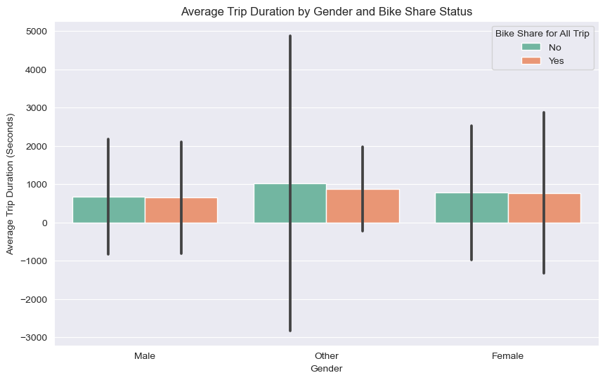

```python
plt.figure(figsize=(10, 6))

# Using a bar plot to represent the multivariate relationships
sns.barplot(data=bike,
            x='member_gender',
            y='duration_sec',
            hue='bike_share_for_all_trip',
            ci='sd',  # Showing standard deviation as error bars
            palette='Set2')

plt.title('Average Trip Duration by Gender and Bike Share Status')
plt.xlabel('Gender')
plt.ylabel('Average Trip Duration (Seconds)')

# Optional: Add user type as another categorical variable for more depth
plt.legend(title='Bike Share for All Trip', loc='upper right')

# Display the plot
plt.show()
```

##### The "Other" gender group has the longest travel duration for both bike-sharing and non-bike-sharing trips, followed by females, and then males.

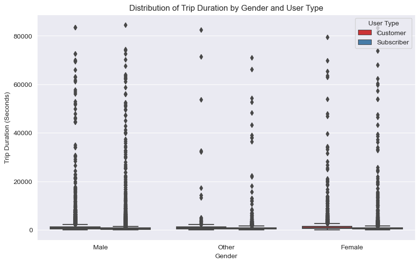

```python
plt.figure(figsize=(10, 6))

# Using a box plot to represent the distribution of trip durations
sns.boxplot(data=bike,
            x='member_gender',
            y='duration_sec',
            hue='user_type',
            palette='Set1')

plt.title('Distribution of Trip Duration by Gender and User Type')
plt.xlabel('Gender')
plt.ylabel('Trip Duration (Seconds)')

plt.legend(title='User Type', loc='upper right')

# Display the plot
plt.show()
```

##### For both subscribers and customers, the group with "other" gender had the longest trip durations, followed by females, and then males.

## Conclusions

> The average trip duration is approximately 703 seconds.

> User Types: Subscribers dominate the user base, accounting for about 90% of the total users.

> Gender Differences: The average trip duration is longer for females compared to males, and the "Other" gender group consistently has the longest trip durations across different categories.

```python
!python -m nbconvert --to html Ford_GoBike_Part_1.ipynb
```

```
[NbConvertApp] Converting notebook Ford_GoBike_Part_1.ipynb to html
[NbConvertApp] WARNING | Alternative text is missing on 19 image(s).
[NbConvertApp] Writing 2040584 bytes to Ford_GoBike_Part_1.html
```